# Introduction

For this project, you will act as a data researcher for the World Health Organization. You will investigate if there is a strong correlation between the economic output of a country and the life expectancy of its citizens.

During this project, you will analyze, prepare, and plot data, and seek to answer questions in a meaningful way.

**Focusing Questions**:

- Has life expectancy increased over time in the six nations?
- Has GDP increased over time in the six nations?
- Is there a correlation between GDP and life expectancy of a country?
- What is the average life expactancy in these nations?
- What is the distribution of that life expectancy?

GDP Source: [World Bank](https://data.worldbank.org/indicator/NY.GDP.MKTP.CD) national accounts data, and OECD National Accounts data files.

Life expectancy Data Source: [World Health Organization](http://apps.who.int/gho/data/node.main.688)

## Step 1. Import Python Modules

```python
from matplotlib import pyplot as plt
import pandas as pd
import seaborn as sns
```

## Step 2. Prep The Data

To look for connections between GDP and life expectancy you will need to load the datasets into DataFrames so that they can be visualized.

Load **all_data.csv** into a DataFrame called `df`. Then, quickly inspect the DataFrame.

```python
df = pd.read_csv('all_data.csv')
print(df.head())
```

```
  Country  Year  Life expectancy at birth (years)           GDP
0   Chile  2000                              77.3  7.786093e+10
1   Chile  2001                              77.3  7.097992e+10
2   Chile  2002                              77.8  6.973681e+10
3   Chile  2003                              77.9  7.564346e+10
4   Chile  2004                              78.0  9.921039e+10
```

## Step 3. Examine The Data

The datasets are large and it may be easier to view the entire dataset locally on your computer. You can open the CSV files directly from the folder you downloaded for this project.

Let's learn more about our data:

- GDP stands for **G**ross **D**omestic **P**roduct. GDP is a monetary measure of the market value of all final goods and services produced in a time period.
- The GDP values are in current US dollars.

What six countries are represented in the data?

```python
# Chile, China, Germany, Mexico, US, Zimbabwe.
```

What years are represented in the data?

```python
# 2000-2015
```

## Step 4. Tweak The DataFrame

```python
print(df.head())
```

```
  Country  Year  Life expectancy at birth (years)           GDP
0   Chile  2000                              77.3  7.786093e+10
1   Chile  2001                              77.3  7.097992e+10
2   Chile  2002                              77.8  6.973681e+10
3   Chile  2003                              77.9  7.564346e+10
4   Chile  2004                              78.0  9.921039e+10
```

What do you notice? The first two column names are one word each, and the third is five words long! `Life expectancy at birth (years)` is descriptive, which will be good for labeling the axis, but a little difficult to wrangle for coding the plot itself.

**Revise The DataFrame Part A:**

```python
df.rename(columns={
    'Life expectancy at birth (years)': 'LEABY'} ,
    inplace=True)
```

```python
print(df.head())
```

```
  Country  Year  LEABY           GDP
0   Chile  2000   77.3  7.786093e+10
1   Chile  2001   77.3  7.097992e+10
2   Chile  2002   77.8  6.973681e+10
3   Chile  2003   77.9  7.564346e+10
4   Chile  2004   78.0  9.921039e+10
```

## Step 5. Bar Charts To Compare Average

To take a first high level look at both datasets, create a bar chart for each DataFrame:

A) Create a bar chart from the data in `df` using `Country` on the x-axis and `GDP` on the y-axis.

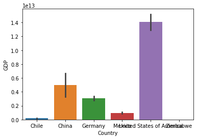

```python
sns.barplot(data=df, x='Country', y='GDP')
plt.show()
```

B) Create a bar chart using the data in `df` with `Country` on the x-axis and `LEABY` on the y-axis.

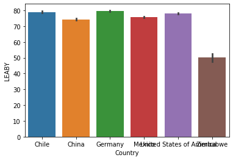

```python
sns.barplot(data=df, x='Country', y='LEABY')
plt.show()
```

## Step 6. Violin Plots To Compare Life Expectancy Distributions

Another way to compare two datasets is to visualize the distributions of each and to look for patterns in the shapes.

We have added the code to instantiate a figure with the correct dimensions to observe detail. Create an `sns.violinplot()` for the dataframe `df` and map `Country` and `LEABY` as its respective `x` and `y` axes.

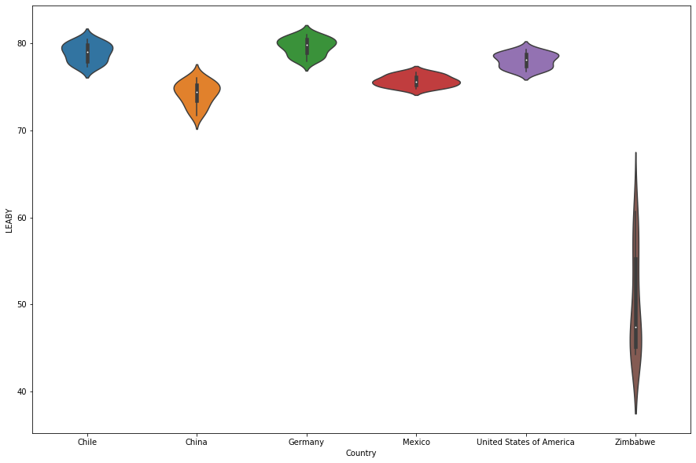

```python
fig = plt.subplots(figsize=(15, 10))
sns.violinplot(data=df, x='Country', y='LEABY')
plt.show()
```

What do you notice about this distribution? Which country's life expactancy has changed the most?

```python
 # Zimbabwe life expectancy has changed the most
```